# Statistics 651 Linear Regression

Winter 2026

## Objectives

1. Specify, fit, and assess multiple linear regression models
2. Use shrinkage priors for variable “selection”
3. Extend inference framework to models with unknown covariance structures
4. Fit nonlinear effects using linear models

## Resources

- BDA3: Ch 14
- BIDA: Ch 7
- Hoff: Ch 9

# Motivation

## Joint multivariate Normal

Consider the real-valued vector $(y, \boldsymbol{x}) \sim \mbox{Normal}_{p+1}(\boldsymbol{\mu}, \boldsymbol{\Sigma})$ where

$$\boldsymbol{\mu} = \begin{pmatrix} \mu_y \\ \boldsymbol{\mu}_x \end{pmatrix}, \qquad \boldsymbol{\Sigma} = \begin{pmatrix} \sigma_y^2 & \boldsymbol{\sigma}_{yx} \\ \boldsymbol{\sigma}_{xy} & \boldsymbol{\Sigma}_x \end{pmatrix} \, .$$
What is the conditional distribution of $y \mid \boldsymbol{x}$?

## Joint multivariate Normal

What if $\boldsymbol{x}$ isn’t random, or we only care about the conditional distribution $y \mid \boldsymbol{x}$?

# Model setup

## Linear regression notation

$n$:

$p$:

$\boldsymbol{y}$:

$\boldsymbol{X}$:

$\boldsymbol{x}_i$:

## Linear regression model

**Classic regression model**

Let $y_i \in \mathbb{R}$, $\boldsymbol{x}_i \in 1 \times \mathbb{R}^p$, and $\boldsymbol{\beta} \in \mathbb{R}^{p+1}$. The model is

$$y_i = \boldsymbol{x}_i^\top \boldsymbol{\beta} + \epsilon_i\, , \quad \epsilon_i \overset{\text{iid}}{\sim}\mbox{Normal}(0, \sigma^2),$$
where $\boldsymbol{x}_i^\top \boldsymbol{\beta} = 1 \beta_0 + x_{i,1} \beta_1 + \ldots + x_{i,p} \beta_p$.

Equivalent likelihood setup:

$$y_i \mid \boldsymbol{\beta}, \sigma^2 \overset{\text{ind}}{\sim} \mbox{Normal}(\boldsymbol{x}_i^\top \boldsymbol{\beta}, \, \sigma^2)$$

with matrix form:

$$\boldsymbol{y} \mid \boldsymbol{\beta}, \sigma^2 \overset{\text{ind}}{\sim} \mbox{Normal}_n(\boldsymbol{X} \boldsymbol{\beta}, \, \sigma^2 \boldsymbol{I})$$

## Design matrix

The design matrix $\boldsymbol{X}$ contains the predictors (covariates).

- First column of 1s (corresponding to $\beta_0$), unless $\boldsymbol{y}$ has been centered
- Columns of $\boldsymbol{X}$ with non-categorical information may be centered/scaled
- Can encode continuous and categorical predictors

Categorical predictors:

## Design matrix

The design matrix $\boldsymbol{X}$ should be full rank.

- If not:
  - $(\boldsymbol{X}^\top \boldsymbol{X})$ is not positive definite and not invertible
  - $\boldsymbol{\beta}$ is not identifiable (in the likelihood)
- Highly correlated columns in $\boldsymbol{X}$ cause similar problems

## Likelihood

If $\boldsymbol{y} \mid \boldsymbol{\beta}, \sigma^2 \overset{\text{ind}}{\sim} \mbox{Normal}_n(\boldsymbol{X} \boldsymbol{\beta}, \, \sigma^2 \boldsymbol{I})$,

$f^n(\boldsymbol{y} \mid \boldsymbol{\beta}, \sigma^2) =$

# Priors for linear regression

## Noninformative prior

**Noninformative prior**

$\pi(\boldsymbol{\beta}, \sigma^2) \propto \frac{1}{\sigma^2}$

This is equivalent to using $\pi(\boldsymbol{\beta}, \log(\sigma)) \propto 1$, and is the Jeffreys prior.

Then we can write $\pi(\boldsymbol{\beta}, \sigma^2 \mid \boldsymbol{y}) = \pi(\sigma^2 \mid \boldsymbol{y}) \times \pi(\boldsymbol{\beta} \mid \sigma^2, \boldsymbol{y})$

(See [Normal-Inverse-Gamma distribution](https://en.wikipedia.org/wiki/Normal-inverse-gamma_distribution))

where

$\pi(\sigma^2 \mid \boldsymbol{y}) \propto$

## Noninformative prior

**Prior**: $\pi(\boldsymbol{\beta}, \sigma^2) \propto \frac{1}{\sigma^2}$

**Posterior**: $\pi(\boldsymbol{\beta}, \sigma^2 \mid \boldsymbol{y}) = \pi(\sigma^2 \mid \boldsymbol{y}) \times \pi(\boldsymbol{\beta} \mid \sigma^2, \boldsymbol{y})$

with

$\sigma^2 \mid \boldsymbol{y} \sim \mbox{Inv-Gamma}(\frac{n-p-1}{2}, \frac{(n-p-1)s_e^2}{2})$

where $s_e^2 = (\boldsymbol{y} - \boldsymbol{X}\hat{\boldsymbol{\beta}})^\top(\boldsymbol{y} - \boldsymbol{X}\hat{\boldsymbol{\beta}}) / (n - p - 1)$ and $\hat{\boldsymbol{\beta}} = (\boldsymbol{X}^\top \boldsymbol{X})^{-1}\boldsymbol{X}^\top \boldsymbol{y}$.

$\pi(\boldsymbol{\beta} \mid \sigma^2, \boldsymbol{x}) \propto$

## Fully conjugate prior

**Conjugate prior**

**Prior** $\pi(\boldsymbol{\beta}, \sigma^2) = \mbox{Inv-Gamma}\left(\sigma^2; \, \frac{n_0}{2}, \, \frac{n_0 s_0^2}{2} \right) \times \mbox{Normal}_{p+1}\left( \boldsymbol{\beta} ; \, \boldsymbol{b}_0, \, \sigma^2 \boldsymbol{V}_0 \right)$

$n_0$:

$s_0^2$:

$\boldsymbol{b}_0$:

$\boldsymbol{V}_0$:

## Fully conjugate prior

**Posterior**

$\pi(\boldsymbol{\beta}, \sigma^2 \mid \boldsymbol{y}) = \mbox{Inv-Gamma}\left(\sigma^2; \, \frac{n_1}{2}, \, \frac{n_1 s_1^2}{2} \right) \times \mbox{Normal}_{p+1}\left( \boldsymbol{\beta} ; \, \boldsymbol{b}_1, \, \sigma^2 \boldsymbol{V}_1 \right)$

$n_1=$

$n_1s_1^2=$

$\boldsymbol{V}_1=$

$\boldsymbol{b}_1=$

Details available at [Bayesian linear regression Wikipedia page](https://en.wikipedia.org/wiki/Bayesian_linear_regression).

## Zellner’s $g$-prior<sup>1</sup>

What happens (in the conjugate model) if we set $\boldsymbol{V}_0 = g \times (\boldsymbol{X}^\top \boldsymbol{X})^{-1}$ for $g > 0$?

$\boldsymbol{V}_1=$

$\boldsymbol{b}_1=$

[^1]: Zellner, A. (1986). “On Assessing Prior Distributions and Bayesian Regression Analysis with g Prior Distributions”. In Goel, P.; Zellner, A. (eds.). Bayesian Inference and Decision Techniques: Essays in Honor of Bruno de Finetti. Studies in Bayesian Econometrics and Statistics. Vol. 6. New York: Elsevier. pp. 233–243. ISBN 978-0-444-87712-3.

## Zellner’s $g$-prior

- Hoff notes that $g$-priors (with $\boldsymbol{b}_0 = \boldsymbol{0}$) yield posterior invariance to scaling in $\boldsymbol{X}$.
- $g$-priors can be helpful in variable selection.
- How to choose $g$?

Common choices:

- $g = 1$
- $g = n$
- $g \sim \mbox{Inv-Gamma}$
- $g \sim \Pi_g$

Options for $\Pi_g$ are discussed in [Liang et al., (2008)](https://doi.org/10.1198/016214507000001337).

## Conditionally conjugate prior

**Conditionally conjugate prior**

$\pi(\boldsymbol{\beta}, \sigma^2) = \mbox{Normal}_{p+1}\left( \boldsymbol{\beta} ; \, \boldsymbol{b}_0, \,\boldsymbol{V}_0 \right) \times \mbox{Inv-Gamma}\left(\sigma^2; \, \frac{n_0}{2}, \, \frac{n_0 s_0^2}{2} \right)$

Posterior **complete** (or **full**) **conditionals**:

$\boldsymbol{\beta} \mid \sigma^2, \boldsymbol{y} \sim \mbox{Normal}_{p+1}(\boldsymbol{b}_1, \boldsymbol{V}_1)$

with $\boldsymbol{V}_1 = \left( \boldsymbol{V}_0^{-1} + \frac{1}{\sigma^2} \boldsymbol{X}^\top \boldsymbol{X}\right)^{-1}$ and $\boldsymbol{b}_1 = \boldsymbol{V}_1 \left( \boldsymbol{V}_0^{-1} \boldsymbol{b}_0 + \frac{1}{\sigma^2} \boldsymbol{X}^\top \boldsymbol{X} \hat{\boldsymbol{\beta}} \right)$,

$\sigma^2 \mid \boldsymbol{\beta}, \boldsymbol{y} \sim \mbox{Inv-Gamma}\left(\frac{n_1}{2}, \, \frac{n_1 s_1^2}{2}\right)$

with $n_1 = n_0 + n$ and $n_1 s_1^2 = n_0 s_0^2 + (\boldsymbol{y} - \boldsymbol{X}\boldsymbol{\beta})^\top (\boldsymbol{y} - \boldsymbol{X}\boldsymbol{\beta})$.

## Error variance

Common alternatives to the Inverse-Gamma prior on $\sigma^2$ include:

- Uniform on $\sigma$
- Half-Cauchy on $\sigma$

Both are discussed in the slides on the Normal model.

The posterior complete conditional density is $\pi(\sigma^2 \mid \boldsymbol{\beta}, \boldsymbol{y}) \propto \exp\left( -\frac{1}{2\sigma^2} (\boldsymbol{y} - \boldsymbol{X}\boldsymbol{\beta})^\top (\boldsymbol{y} - \boldsymbol{X}\boldsymbol{\beta}) \right) \times \pi(\sigma^2)$.

## Linear regression

**Example: Oxygen uptake**

Consider the data on Oxygen uptake<sup>1</sup> discussed in Ch 9.1 of Hoff, and available in this [R script](https://www2.stat.duke.edu/~pdh10/FCBS/Replication/chapter9.R).

Fit the linear model $y_i = \beta_0 + \beta_1 \texttt{is.aerobic}_i + \beta_2 \texttt{age}_i + \beta_3 \texttt{is.aerobic}_i \times \texttt{age}_i + \epsilon_i$ with $\epsilon_i \overset{\text{iid}}{\sim} \mbox{Normal}(0, \sigma^2)$ using one of the prior specifications given above

- by coding your own Gibbs sampler, and
- using a PPL.

Then fit a model without an interaction and use a model-selection criterion to decide between the two.

[^2]: from Kuehl RO (2000) *Design of Experiments: Statistical Principles of Research Design and Analysis*. Duxbury Press

## Residuals

Types of raw residuals under a Bayesian model

- $y_i - \mathbb{E}_{F(y_i \mid \hat{\boldsymbol{\theta}})}(y_i)$ (where $\hat{\boldsymbol{\theta}}$ is a posterior point estimate)
- $y_i - \mathbb{E}_{\Pi(\boldsymbol{\theta} \mid \boldsymbol{y})}( \mathbb{E}_{F(y_i \mid \boldsymbol{\theta})}(y_i) )$
- Posterior distribution of $y_i - \mathbb{E}_{F(y_i \mid \boldsymbol{\theta})}(y_i)$
- Any of the above where the posterior is computed excluding observation $i$
- Any of the above using summary other than the mean

## Predictive distributions

Notes:

- Although predictive distributions are available in closed form for conjugate regression models, we typically just sample from these distributions using MCMC.
- Predictive densities $f_i(y_i^* \mid \boldsymbol{y})$ depend on an associated covariate vector $\boldsymbol{x}_i^*$.

# Variable selection

## Variable selection

Modern data sets often come with *many* predictors.

In some cases $p > n$. What’s the problem here?

Given what we’ve covered so far, what approach might you take to variable selection?

## Variable selection

**Discrete parameters for model selection**

Let $\boldsymbol{\gamma} \in \{ 0, 1\}^p$ be a binary vector where $\gamma_\ell = 1$ means the $\ell$th variable is included in $\boldsymbol{X}$.

Thus, given $\boldsymbol{\gamma}$, there is an associated $\boldsymbol{X}_\boldsymbol{\gamma}$ and $\boldsymbol{\beta}_\boldsymbol{\gamma}$.

Alternatively we could keep the full $\boldsymbol{X}$ and ${\boldsymbol{\beta}}$ where ${\beta}_\ell = 0$ if $\gamma_\ell = 0$. This approach masks that $\beta_\ell$ has a different role under distinct configurations of $\boldsymbol{\gamma}$.

Two approaches:

1. Select (or average) among the $2^p$ possible models.
2. Shrink posterior distuributions of $\beta_\ell$ toward 0.

## Variable selection

Following the model-averaging approach, we can specify the following hierarchical model

$$\begin{align}
\boldsymbol{y} \mid \boldsymbol{\gamma}, \boldsymbol{\beta}_\boldsymbol{\gamma}, \sigma^2 &\sim \mbox{Normal}(\boldsymbol{X}_\boldsymbol{\gamma} \boldsymbol{\beta}_\boldsymbol{\gamma}, \, \sigma^2) \, , \\
\boldsymbol{\beta}_\boldsymbol{\gamma}, \sigma^2 \mid \boldsymbol{\gamma} &\sim \mbox{Normal}(\boldsymbol{\beta}_{\boldsymbol{\gamma}} \mid \sigma^2) \times \mbox{Inv-Gamma}(\sigma^2) \, , \\
\boldsymbol{\gamma} &\sim \Pi(\boldsymbol{\gamma}).
\end{align}$$

Using the conjugate prior on the second line, we can integrate out $(\boldsymbol{\beta}_{\boldsymbol{\gamma}}, \sigma^2)$ to get

$f^n(\boldsymbol{y} \mid \boldsymbol{\gamma})=$

which is often called **marginal likelihood** or model **evidence**<sup>1</sup>.

[^3]: See [Bayesian linear regression Wikipedia page](https://en.wikipedia.org/wiki/Bayesian_linear_regression) for pdf of $f^n(\boldsymbol{y} \mid \boldsymbol{\gamma})$

## Variable selection

With a marginal likelihood, the collapsed model becomes

$$\begin{align}
\boldsymbol{y} \mid \boldsymbol{\gamma} &\sim F^n(\boldsymbol{y} \mid \boldsymbol{\gamma}) \, , \\
\boldsymbol{\gamma} &\sim \Pi(\boldsymbol{\gamma}).
\end{align}$$

What could we use for $\Pi(\boldsymbol{\gamma})$?

Options for calculating the posterior:

## Variable selection

**Posterior calculation**

Choose a prior for $\boldsymbol{\gamma}$ and write the resulting (marginal) posterior pmf.

# Shrinkage priors

## Regularization

How do regularized methods like Ridge and LASSO estimate $\boldsymbol{\beta}$?

## Regularization

**Equivalence of penalized maximum likelihood and MAP**

Show that the maximum a posteriori (MAP) estimate of $\boldsymbol{\beta}$ under a Normal prior (with mean $\boldsymbol{b}_0 = \boldsymbol{0}$ and covariance $v_0 \boldsymbol{I}_p$) is the Ridge estimator.

## Scale mixtures of Normals

Recall from earlier

$$\begin{align}
Y \mid \sigma^2 &\sim \mbox{Normal}(0, \sigma^2) \\
\sigma^2 &\sim \mbox{Inv-Gamma}
\end{align}$$

What is the marginal distribution of $Y$?

## Global-local shrinkage priors

**Definition**

Let $\boldsymbol{y} \mid \boldsymbol{\theta}, \sigma^2 \sim \mbox{Normal}_J(\boldsymbol{\theta}, \, \sigma^2 \boldsymbol{I})$ and
$$\theta_j \mid \{ \lambda_j \}, \tau \overset{\text{ind}}{\sim} \mbox{Normal}(0, \, \lambda_j^2 \, \tau^2)$$
with
$$\lambda_j^2 \sim \pi_j(\lambda_j^2)\, , \quad (\tau^2, \, \sigma^2) \sim \pi(\tau^2, \, \sigma^2)\, ,$$
for $j = 1, \ldots, J$.

This forms a class called **global-local shrinkage priors**<sup>1</sup>.

See [Bhadra et al., (2019)](https://www.jstor.org/stable/26874188) for a review.

The general setting above is called the **Normal means model**.

[^4]: [Polson and Scott (2011)](https://doi.org/10.1093/acprof:oso/9780199694587.003.0017)

## Global-local shrinkage priors

Properties:

- $\tau$ is a global shrinkage parameter that pulls all $\theta_j$ toward 0.
- $\lambda_j$ is a local shrinkage parameter specific to $\theta_j$.
- Marginal priors for $\theta_j$ are shaped to have “spikes” near 0 and heavy tails.
- Related to models for discrete variable inclusion (that is, using $\gamma_j$) through the shrinkage weight $\kappa_j = (1 + \lambda_j^2 \, \tau^2)^{-1} \in (0, 1)$, where
  $$\mathbb{E}(\theta_j \mid y_j) = [1 - \mathbb{E}(\kappa_j \mid y_j)] \times y_j \, .$$
  - What does it mean if $\kappa_j \rightarrow 1$?

## Horseshoe prior

**Definition**

Assume the Normal-means setup from before:

$\boldsymbol{y} \mid \boldsymbol{\theta}, \sigma^2 \sim \mbox{Normal}_J(\boldsymbol{\theta}, \, \sigma^2 \boldsymbol{I})$ and $\theta_j \mid \lambda_j, \tau \overset{\text{ind}}{\sim} \mbox{Normal}(0, \, \lambda_j^2 \, \tau^2)$, $j = 1, \ldots, J$.

The **Horseshoe prior**<sup>1</sup> is a global-local shrinkage prior with

$$\lambda_j \overset{\text{iid}}{\sim} \mbox{Cauchy}^+(0,1) \, , \quad \tau \mid \sigma \sim \mbox{Cauchy}^+(0,\sigma) \, .$$

[^5]: [Carvalho et al., (2010)](https://www.jstor.org/stable/25734098)

## Horseshoe prior

Why the name Horseshoe?

If $\sigma = \tau = 1$, then the marginal prior for $\kappa_j = (1 + \lambda_j^2)^{-1}$ is $\mbox{Beta}(0.5, 0.5)$.

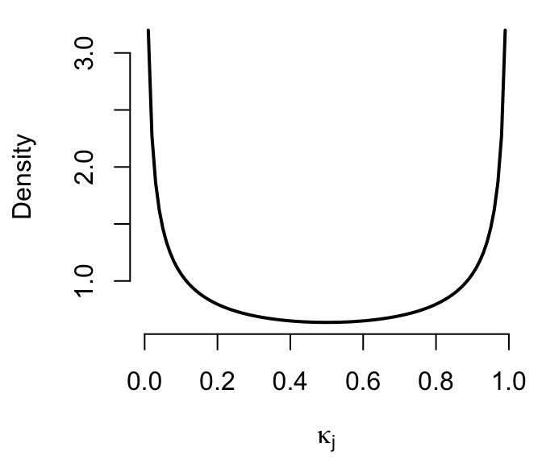

## Horseshoe in regression

Applying the prior to the coefficients in regression, the Horseshoe prior yields the hierarchical model

$$\begin{align}
\boldsymbol{y} \mid \beta_0, \boldsymbol{\beta}, \sigma^2 &\sim \mbox{Normal}_n( \boldsymbol{1} \beta_0 + \boldsymbol{X}\boldsymbol{\beta}, \, \sigma^2 \boldsymbol{I}) \, , \\
\beta_0 \sim \Pi_{\beta_0} \, , \quad \beta_j \mid \{ \lambda_j \}, \tau &\overset{\text{ind}}{\sim} \mbox{Normal}(0, \, \lambda_j^2 \, \tau^2) \, , \quad j = 1, \ldots, p, \\
\lambda_j &\overset{\text{iid}}{\sim} \mbox{Cauchy}^+(0,1) \, , \quad j = 1, \ldots, p, \\
\tau \mid \sigma &\sim \mbox{Cauchy}^+(0,\sigma) \, , \\
\sigma &\sim \Pi_\sigma \, .
\end{align}$$

Note that here $\boldsymbol{X}$ does *not* have a column of 1s.

If there is no interest in the intercept, one option is to pre-center $\boldsymbol{y}$ and set $\beta_0 = 0$.

## Global-local shrinkage in regression

**Advice**

Shrinkage (or penalized) methods are typically fit using $\boldsymbol{X}$ that

- has been centered and scaled (each column), and
- does *not* contain a column of 1s for an intercept.

## Global-local shrinkage priors

Advantages:

- Penalized likelihood methods typically offer point estimates *only*, whereas full inference is available with a posterior distribution.
- Only *one* model fit!

Disadvantages:

- Nothing is shrunk to exactly 0 $\rightarrow$ No explicit inclusion parameter $\gamma_j \in \{0,1\}$

## Shrinkage priors

**Example: Spotify data**

Consider the [Spotify data on Kaggle](https://www.kaggle.com/datasets/maharshipandya/-spotify-tracks-dataset/data) that measures several characteristics of tens of thousands of songs like: explicit language, danceability, energy, loudness, speechiness, acousticness, liveliness, tempo, genre, etc.

Can we use these characteristics to predict song popularity?

Fit a linear regression with continuous shrinkage priors to aid with regularization / variable selection. Use the $\kappa_j$ values to make determinations about variable inclusion.

# Model extensions

# Unknown error structure

## Unknown error structure

Consider the following generalization of the regression model:

$$\boldsymbol{y} = \boldsymbol{X} \boldsymbol{\beta} + \boldsymbol{\epsilon}, \quad \boldsymbol{\epsilon} \sim \mbox{Normal}_n( \boldsymbol{0}, \boldsymbol{\Sigma}) \, ,$$
where $\boldsymbol{\Sigma}$ is positive definite.

Typically, $\boldsymbol{\Sigma}$ is not unstructured ($n(n+1)/2$ parameters), but parameterized.

## Unknown error structure

**Common parameterizations of $\boldsymbol{\Sigma}$:**

**Unequal variances**
$$\boldsymbol{\Sigma} = \mbox{diag}(\sigma_1^2, \sigma_2^2, \ldots, \sigma_n^2)$$

**(First order) autocorrelation**
$$\boldsymbol{\Sigma} = \sigma^2 \boldsymbol{R} \quad \text{with} \ \boldsymbol{R}_{i,j} = \rho^{\lvert i-j \rvert} \ \text{for} \ \rho \in (-1, 1)$$

- Assumes observations are in order and equally spaced in time

**Compound symmetric**
$$\boldsymbol{\Sigma} = \rho \boldsymbol{1} \boldsymbol{1}^\top +
\sigma^2 \boldsymbol{I}$$

- Requires $-\frac{\sigma^2}{n-1} < \rho < \sigma^2$

## Unknown error structure

Likelihood:
$$\boldsymbol{y} \mid \boldsymbol{\beta}, \boldsymbol{\Sigma} \sim \mbox{Normal}_n(\boldsymbol{X} \boldsymbol{\beta}, \, \boldsymbol{\Sigma})$$

MCMC can procced with a Gibbs sampler that uses

- the above likelihood for parameters in $\boldsymbol{\Sigma}$ given $\boldsymbol{\beta}$, $\boldsymbol{y}$, and
- the following trick that allows us to use all of the work from previous slides to update $\boldsymbol{\beta}$ given $\boldsymbol{\Sigma}$, $\boldsymbol{y}$…

## Unknown error structure

**Proposition**

The following are equivalent model specifications:

$$\boldsymbol{y} \mid \boldsymbol{\beta}, \boldsymbol{\Sigma} \sim \mbox{Normal}_n(\boldsymbol{X} \boldsymbol{\beta}, \, \boldsymbol{\Sigma})$$
and

$$\boldsymbol{y}^* \mid \boldsymbol{\beta}, \boldsymbol{\Sigma} \sim \mbox{Normal}_n(\boldsymbol{X}^* \boldsymbol{\beta}, \, \boldsymbol{I})$$
where $\boldsymbol{y}^* = \boldsymbol{L}^{-1}\boldsymbol{y}$ and $\boldsymbol{X}^* = \boldsymbol{L}^{-1}\boldsymbol{X}$ for Cholesky factor $\boldsymbol{L}$ such that $\boldsymbol{L}\boldsymbol{L}^\top = \boldsymbol{\Sigma}$.

Proof:

# Hierarchical linear models

## Hierarchical linear models

**Example (random intercepts model)**

Consider the model

$$y_i = \alpha_{g_i} + \boldsymbol{x}_i^\top \boldsymbol{\beta} + \epsilon_i \, ,$$
where intercepts $\alpha_g$ correspond to groups $g \in \{1, \ldots, K \}$.

What if $\alpha_1 = \ldots = \alpha_K = \alpha$?

What if $\alpha_g$ are all totally independent?

What if $\alpha_g$ are *conditionally* independent, given a hierarchical structure?

Write a hierarchical specification that compromises between the two extremes and sketch a Gibbs sampling scheme.

# Nonlinear models

## Basis expansion

Nonlinear relationships between $x$ and $y$ can be learned with *linear models* using transformations of $x$.

General idea with one input $x$:

$$y_i = \beta_0 + \sum_{\ell = 1}^p h_\ell(x_i) \beta_\ell + \epsilon_i$$
where $\{ h_\ell(\cdot) : \ell = 1, \ldots, p \}$ form a basis expansion for $x$.

Common bases:

- Polynomial
- Spline
- Trigonometric
- Wavelet

## Basis expansion

**Example: harmonic regression**

$$y_i = \beta_0 + \sum_{\ell = 1}^2 \alpha_\ell \cos(2\pi \ell t_i) + \beta_\ell \sin(2\pi \ell t_i) + \epsilon_i$$
which can be written as $\boldsymbol{y} = \boldsymbol{X}\boldsymbol{\beta} + \boldsymbol{\epsilon}$ with

$\boldsymbol{X} =$

$\boldsymbol{\beta} =$

## Basis expansion

Resources:

- BIDA: Ch 15.2
- Chapter 5 of [*Elements of Statistical Learning*](https://hastie.su.domains/ElemStatLearn/) by Hastie, Tibshirani and Friedman
- [Slides by Timothy Hanson](https://people.stat.sc.edu/hansont/stat705/basis.pdf) (co-author of BIDA)